# Lecture 4 Workshop Answers

Dr. Andrew Sackman

1/23/2020

## Exercise 1

In this exercise, we will all have a chance to see how changes in sample size affect the sampling distribution. Please execute the following command five times and report back the numbers you receive. Remember that you can execute previous commands by pressing the “up” arrow key on your keyboard.

```r
round(mean(rnorm(10,100,100)),0)
```

The rnorm(n,mu,sd) function generates a vector of numbers of length n randomly chosen from a normal distribution with specified mean and standard deviation.

Let’s do this again with samples sizes n = 100, and n=10000.

## Exercise 2

We measure the total rainfall in mm for the month of August at each regional airport in Virginia. We obtain the values:

```r
rainfall_totals = c(112, 128, 108, 129, 125, 153, 155, 132, 137)
```

The mean of our values is 131.0 mm, and the variance is 254.5 mm.

1. What is *s*, the standard deviation of these data?

```r
mean = 131.0
variance = 254.5
standard_deviation = sqrt(variance)
print(standard_deviation)
```

```
## [1] 15.95306
```

2. What is *n*, the sample size?

```r
n = length(rainfall_totals)
print(n)
```

```
## [1] 9
```

3. Calculate the standard error of the mean.

```r
standard_error = standard_deviation/sqrt(n)
print(standard_error)
```

```
## [1] 5.317685
```

4. Using the 2SE rule of thumb, calculate an approximate 95% confidence interval for the mean. Provide the lower and upper limits.

```r
min_conf_interval = mean - 2 * standard_error
max_conf_interval = mean + 2 * standard_error
print(paste('We can be 95% confident that the population mean falls between ',toString(min_conf_interval),' and ',toString(max_conf_interval),'.'))
```

```
## [1] "We can be 95% confident that the population mean falls between  120.364629244304  and  141.635370755696 ."
```

## Exercise 3

In a poll of 1641 people carried out in Canada in November 2005, 73% of people surveyed agreed with the statement that “you don’t really expect that politicians will keep their election promises once they are in power” (CBC News 2005).

1. What is the parameter being estimated?

*The parameter being estimated is the percentage of people in Canada who agree with the statement.*

2. What is the value of the sample estimate?

*The sample estimate is 73%*

3. What is the sample size?

*The sample size,* n*, is 1641.*

4. The poll also reported that “the results are considered accurate within 2.5 percentage points, 19 times out of 20.” Explain what this statement likely refers to.

*They are refering to a 95% confidence interval.*

## Exercise 4

Goldman et al. (1988) analyzed data on 405 patients with white blood cell cancer (chronic myelogenous leukemia) who received bone marrow transplants. They estimated the probability of relapse within 4 years of treatment to be 0.19, with a 95% confidence of 0.12 to 0.28. Which of the following statements are true?

1. The population proportion is 0.19. **b) The population proportion is likely to be between 0.12 and 0.28.**
2. There is a 95% chance that the population proportion is between 0.12 and 0.28.
3. A population proportion of 0.30 is plausible.

## Exercise 5

Amorphophallus johnsonii is a plant growing in West Africa, and it is better known as a “corpse-flower.” Its common name comes from the fact that when it flowers, it gives off a “powerful aroma of rotting fish and faeces” (Beath 1996). The flowers smell this way because their principal pollinators are carrion beetles, who are attracted to such a smell. Beath (1996) observed the number of carrion beetles (Phaeochrous amplus) that arrive per night to flowers of this species. The data are as follows:

```r
beetle_counts = c(51, 45, 61, 76, 11, 117, 7, 132, 52, 149)
```

1. What is the mean and standard deviation of beetles per flower?

```r
mean(beetle_counts)
```

```
## [1] 70.1
```

```r
sd(beetle_counts)
```

```
## [1] 48.50074
```

2. What is the standard error of this estimate of the mean?

```r
sd(beetle_counts)/sqrt(length(beetle_counts))
```

```
## [1] 15.33728
```

3. Give an approximate 95% confidence interval of the mean. Provide lower and upper limits.

4. If you had been given 25 data points instead of 10, would you expect the mean to be greater, less than, or about the same as the mean of this sample?

*We would expect the mean to be the same.*

5. If you had been given 25 data points instead of 10, would you have expected the standard deviation to be greater, less than, or about the same as this sample?

*We would expect the standard deviation to be the same.*

6. If you had been given 25 data points instead of 10, would you have expected the standard error of the mean to be greater, less than, or about the same as this sample?

*We would expect the standard error to be smaller.*

7. If you had been given 25 data points instead of 10, would you have expected the sample mean to be closer to or futher from the true population mean?

*We would expect that on average the sample mean will be closer to the true population mean with a larger sample size.*

## Exercise 6

```r
widths = c(6.1,5.3,6.0,6.1,6,5.7,6.1,5.1,5.9,6.1,6.2,6,6.2,6.2,6.1,6.2,6,5.7,6.2,5.8,5.,6.3,6.2,5.7,6.0,5.8,5.7,5.9,6.1,5.7,5.9,6.1,5.9,6.0,5.4,4.7,5.9,6.1,5.9,5.9,6.1,6.1)
```

1. Construct a table of frequency data for these measurements.

```r
table(widths)
```

```
## widths
## 4.7   5 5.1 5.3 5.4 5.7 5.8 5.9   6 6.1 6.2 6.3
##   1   1   1   1   1   5   2   7   6  10   6   1
```

2. Now plot the data as a histogram. Be sure to include informative axes.

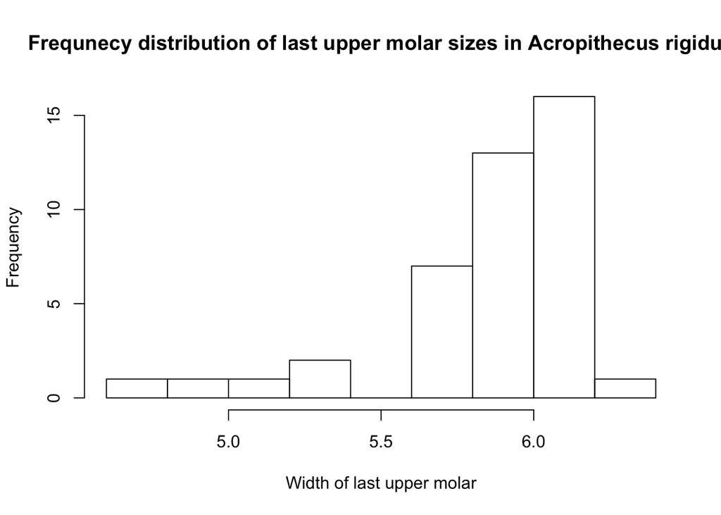

```r
hist(widths,xlab='Width of last upper molar',ylab='Frequency',main='Frequnecy distribution of last upper molar sizes in Acropithecus rigidus')
```

3. Describe the shape of this distribution.